# Kepler Exoplanet Data Analysis

## Girik Tripathi (UID -121127839)

## Palak Wadhwa (UID -1210999925 )

## Sriniketh Shankar (UID - 121113580)

## Harshitha Murali (UID- 121302984)

# Introduction

For centuries, the night sky has been a source of wonder and intrigue. The stars above us, scattered across the cosmos have inspired questions about our place in the universe. Are we alone? Could other worlds exist beyond our solar system, orbiting distant stars, and what might they look like? These profound questions took a major step closer to being answered with the launch of NASA's Kepler Space Telescope, a mission that fundamentally reshaped our understanding of planetary systems and the possibility of extraterrestrial life.

The Kepler mission set out with a bold and ambitious goal: to determine the frequency of Earth-like planets in our galaxy. It observed a carefully chosen patch of the Milky Way, monitoring the brightness of over 150,000 stars continuously for years. By detecting the faint and periodic dimming caused by planets passing in front of their host stars—a phenomenon known as a transit—Kepler uncovered thousands of exoplanets. These discoveries have ranged from gas giants larger than Jupiter to rocky planets smaller than Earth, orbiting in configurations far different from our own solar system. Kepler not only revealed the sheer abundance of planets but also hinted at the diversity and complexity of planetary systems across the galaxy.

The dataset produced by Kepler is massive, intricate, and filled with potential insights. Each data point represents the dynamic relationship between stars and their planets. Analyzing such data requires not only an understanding of astronomy but also the power of modern data science tools and techniques. This is where our journey begins.

In this project, we aim to take a deep dive into Kepler’s data, following the data science pipeline from start to finish. We begin by curating and preprocessing the raw data, ensuring it is clean and ready for analysis. Next, we explore the data through visualization and statistical techniques to uncover patterns and relationships. We then apply machine learning models to predict outcomes, leveraging the vast computational power available to modern scientists. Finally, we synthesize our findings into meaningful insights, connecting the results to the larger narrative of exoplanet discovery and exploration.

Through this process, we aim to demonstrate how the principles of data science can illuminate some of the most complex questions in astronomy. By the end of this tutorial, we hope you will not only have a deeper understanding of the Kepler mission and its data but also an appreciation for the analytical tools that make such discoveries possible.

You can read more about the kepler mission here - https://science.nasa.gov/mission/kepler

The [Kepler Objects of Interest (KOI) dataset](https://exoplanetarchive.ipac.caltech.edu/cgi-bin/TblView/nph-tblView?app=ExoTbls&config=cumulative) is a catalog maintained by NASA's Exoplanet Archive operating at Caltech that contains data from the Kepler Space Telescope, which was designed to discover Earth-like planets in distant solar systems. This dataset provides a wealth of information about celestial objects identified as potential exoplanets. Each entry represents a candidate object, detailing its physical characteristics, orbital properties, and detection metrics.

This project utilizes the KOI dataset to investigate exoplanet classification and determine the likelihood of habitability. The primary goal is to analyze the dataset to distinguish confirmed exoplanets from false positives using data science techniques.

# Data Dictionary

Below is a detailed description of the columns available in the KOI dataset:

```python
# @title
import pandas as pd

data_dict = [
    {"Column": "kepid", "Description": "Unique Kepler ID number assigned to a target star."},
    {"Column": "kepoi_name", "Description": "Unique identifier for the Kepler Object of Interest (KOI)."},
    {"Column": "kepler_name", "Description": "Designated name of the confirmed planet (if applicable)."},
    {"Column": "koi_disposition", "Description": "Disposition of the Kepler Object of Interest: CANDIDATE, CONFIRMED, or FALSE POSITIVE."},
    {"Column": "koi_pdisposition", "Description": "Pipeline disposition: CANDIDATE or FALSE POSITIVE."},
    {"Column": "koi_score", "Description": "Confidence score assigned to the KOI by the Kepler pipeline."},
    {"Column": "koi_fpflag_nt", "Description": "Flag indicating whether the KOI was determined to be a not-transiting object."},
    {"Column": "koi_fpflag_ss", "Description": "Flag indicating whether the KOI was determined to be a stellar eclipsing binary."},
    {"Column": "koi_fpflag_co", "Description": "Flag indicating whether the KOI was determined to be a centroid offset."},
    {"Column": "koi_fpflag_ec", "Description": "Flag indicating whether the KOI was determined to be an eclipsing binary using statistical tests."},
    {"Column": "koi_period", "Description": "Orbital period of the planet candidate in days."},
    {"Column": "koi_time0bk", "Description": "Transit epoch (Barycentric Kepler Julian Date - 2454833)."},
    {"Column": "koi_duration", "Description": "Duration of the transit in hours."},
    {"Column": "koi_depth", "Description": "Depth of the transit in parts per million (ppm)."},
    {"Column": "koi_prad", "Description": "Radius of the planet candidate in Earth radii."},
    {"Column": "koi_teq", "Description": "Equilibrium temperature of the planet candidate in Kelvin."},
    {"Column": "koi_insol", "Description": "Insolation flux received by the planet candidate in Earth units."},
    {"Column": "koi_model_snr", "Description": "Signal-to-noise ratio of the planet candidate's transit model."},
    {"Column": "koi_steff", "Description": "Effective temperature of the host star in Kelvin."},
    {"Column": "koi_slogg", "Description": "Surface gravity of the host star in cm/s^2."},
    {"Column": "koi_srad", "Description": "Radius of the host star in solar radii."},
    {"Column": "ra", "Description": "Right Ascension of the star in decimal degrees."},
    {"Column": "dec", "Description": "Declination of the star in decimal degrees."},
    {"Column": "koi_kepmag", "Description": "Kepler-band magnitude of the host star."}
]

data_dict_df = pd.DataFrame(data_dict)
data_dict_df
```

|  | Column | Description |
| --- | --- | --- |
| 0 | kepid | Unique Kepler ID number assigned to a target s... |
| 1 | kepoi_name | Unique identifier for the Kepler Object of Int... |
| 2 | kepler_name | Designated name of the confirmed planet (if ap... |
| 3 | koi_disposition | Disposition of the Kepler Object of Interest: ... |
| 4 | koi_pdisposition | Pipeline disposition: CANDIDATE or FALSE POSIT... |
| 5 | koi_score | Confidence score assigned to the KOI by the Ke... |
| 6 | koi_fpflag_nt | Flag indicating whether the KOI was determined... |
| 7 | koi_fpflag_ss | Flag indicating whether the KOI was determined... |
| 8 | koi_fpflag_co | Flag indicating whether the KOI was determined... |
| 9 | koi_fpflag_ec | Flag indicating whether the KOI was determined... |
| 10 | koi_period | Orbital period of the planet candidate in days. |
| 11 | koi_time0bk | Transit epoch (Barycentric Kepler Julian Date ... |
| 12 | koi_duration | Duration of the transit in hours. |
| 13 | koi_depth | Depth of the transit in parts per million (ppm). |
| 14 | koi_prad | Radius of the planet candidate in Earth radii. |
| 15 | koi_teq | Equilibrium temperature of the planet candidat... |
| 16 | koi_insol | Insolation flux received by the planet candida... |
| 17 | koi_model_snr | Signal-to-noise ratio of the planet candidate'... |
| 18 | koi_steff | Effective temperature of the host star in Kelvin. |
| 19 | koi_slogg | Surface gravity of the host star in cm/s^2. |
| 20 | koi_srad | Radius of the host star in solar radii. |
| 21 | ra | Right Ascension of the star in decimal degrees. |
| 22 | dec | Declination of the star in decimal degrees. |
| 23 | koi_kepmag | Kepler-band magnitude of the host star. |

```python
# from google.colab import drive
# drive.mount('/content/drive')
```

```python
# Define paths to datasets
kepler_dataset_path = 'kepler-data.csv'
```

## **Overview**

```python
import pandas as pd

# Load Excel datasets
df = pd.read_csv(kepler_dataset_path)
```

# **Understanding the Dataset**

## **Dataset Overview**

- The dataset contains records related to Kepler space mission observations, specifically regarding planetary candidates.
- Key columns include:
  - `kepoi_name`: Unique identifier for the planetary candidate.
  - `koi_disposition`: Classification of the candidate (e.g., CONFIRMED, FALSE POSITIVE).
  - `koi_score`: Confidence score for the planetary candidate.
  - `koi_period`: Orbital period of the planet in days.
  - `koi_depth`: Transit depth in parts per million (ppm), indicating the size of the planet.
- Key numerical columns (e.g., `koi_score`, `koi_depth`) are crucial for determining planetary characteristics.

```python
print(df.head())
print(df.info())
```

```
   rowid     kepid kepoi_name   kepler_name koi_disposition koi_pdisposition  \
0      1  10797460  K00752.01  Kepler-227 b       CONFIRMED        CANDIDATE
1      2  10797460  K00752.02  Kepler-227 c       CONFIRMED        CANDIDATE
2      3  10811496  K00753.01           NaN  FALSE POSITIVE   FALSE POSITIVE
3      4  10848459  K00754.01           NaN  FALSE POSITIVE   FALSE POSITIVE
4      5  10854555  K00755.01  Kepler-664 b       CONFIRMED        CANDIDATE

   koi_score  koi_fpflag_nt  koi_fpflag_ss  koi_fpflag_co  ...  \
0      1.000              0              0              0  ...
1      0.969              0              0              0  ...
2      0.000              0              1              0  ...
3      0.000              0              1              0  ...
4      1.000              0              0              0  ...

   koi_steff_err2  koi_slogg  koi_slogg_err1  koi_slogg_err2  koi_srad  \
```

[output cut: 72 more lines]

## **Missing Data**

```python
missing_data = df.isnull().sum()
missing_percentage = (missing_data / len(df)) * 100
print(missing_percentage)
df.head()
```

```
rowid                  0.000000
kepid                  0.000000
kepoi_name             0.000000
kepler_name           76.014220
koi_disposition        0.000000
koi_pdisposition       0.000000
koi_score             15.788373
koi_fpflag_nt          0.000000
koi_fpflag_ss          0.000000
koi_fpflag_co          0.000000
koi_fpflag_ec          0.000000
koi_period             0.000000
koi_period_err1        4.746968
koi_period_err2        4.746968
koi_time0bk            0.000000
koi_time0bk_err1       4.746968
koi_time0bk_err2       4.746968
koi_impact             3.795483
koi_impact_err1        4.746968
koi_impact_err2        4.746968
koi_duration           0.000000
koi_duration_err1      4.746968
koi_duration_err2      4.746968
koi_depth              3.795483
koi_depth_err1         4.746968
koi_depth_err2         4.746968
koi_prad               3.795483
koi_prad_err1          3.795483
koi_prad_err2          3.795483
koi_teq                3.795483
koi_teq_err1         100.000000
koi_teq_err2         100.000000
koi_insol              3.356336
koi_insol_err1         3.356336
koi_insol_err2         3.356336
koi_model_snr          3.795483
koi_tce_plnt_num       3.617733
koi_tce_delivname      3.617733
koi_steff              3.795483
koi_steff_err1         4.893350
koi_steff_err2         5.050188
koi_slogg              3.795483
koi_slogg_err1         4.893350
koi_slogg_err2         4.893350
koi_srad               3.795483
koi_srad_err1          4.893350
koi_srad_err2          4.893350
ra                     0.000000
dec                    0.000000
koi_kepmag             0.010456
dtype: float64
```

|  | rowid | kepid | kepoi_name | kepler_name | koi_disposition | koi_pdisposition | koi_score | koi_fpflag_nt | koi_fpflag_ss | koi_fpflag_co | ... | koi_steff_err2 | koi_slogg | koi_slogg_err1 | koi_slogg_err2 | koi_srad | koi_srad_err1 | koi_srad_err2 | ra | dec | koi_kepmag |
| --- | --- | --- | --- | --- | --- | --- | --- | --- | --- | --- | --- | --- | --- | --- | --- | --- | --- | --- | --- | --- | --- |
| 0 | 1 | 10797460 | K00752.01 | Kepler-227 b | CONFIRMED | CANDIDATE | 1.000 | 0 | 0 | 0 | ... | -81.0 | 4.467 | 0.064 | -0.096 | 0.927 | 0.105 | -0.061 | 291.93423 | 48.141651 | 15.347 |
| 1 | 2 | 10797460 | K00752.02 | Kepler-227 c | CONFIRMED | CANDIDATE | 0.969 | 0 | 0 | 0 | ... | -81.0 | 4.467 | 0.064 | -0.096 | 0.927 | 0.105 | -0.061 | 291.93423 | 48.141651 | 15.347 |
| 2 | 3 | 10811496 | K00753.01 | NaN | FALSE POSITIVE | FALSE POSITIVE | 0.000 | 0 | 1 | 0 | ... | -176.0 | 4.544 | 0.044 | -0.176 | 0.868 | 0.233 | -0.078 | 297.00482 | 48.134129 | 15.436 |
| 3 | 4 | 10848459 | K00754.01 | NaN | FALSE POSITIVE | FALSE POSITIVE | 0.000 | 0 | 1 | 0 | ... | -174.0 | 4.564 | 0.053 | -0.168 | 0.791 | 0.201 | -0.067 | 285.53461 | 48.285210 | 15.597 |
| 4 | 5 | 10854555 | K00755.01 | Kepler-664 b | CONFIRMED | CANDIDATE | 1.000 | 0 | 0 | 0 | ... | -211.0 | 4.438 | 0.070 | -0.210 | 1.046 | 0.334 | -0.133 | 288.75488 | 48.226200 | 15.509 |

5 rows × 50 columns

If a column has more than a certain threshold (e.g., 70%) of missing values, consider dropping it.

```python
threshold = 70
columns_to_drop = missing_percentage[missing_percentage > threshold].index
df.drop(columns=columns_to_drop, inplace=True)
```

```python
df.head()
```

|  | rowid | kepid | kepoi_name | koi_disposition | koi_pdisposition | koi_score | koi_fpflag_nt | koi_fpflag_ss | koi_fpflag_co | koi_fpflag_ec | ... | koi_steff_err2 | koi_slogg | koi_slogg_err1 | koi_slogg_err2 | koi_srad | koi_srad_err1 | koi_srad_err2 | ra | dec | koi_kepmag |
| --- | --- | --- | --- | --- | --- | --- | --- | --- | --- | --- | --- | --- | --- | --- | --- | --- | --- | --- | --- | --- | --- |
| 0 | 1 | 10797460 | K00752.01 | CONFIRMED | CANDIDATE | 1.000 | 0 | 0 | 0 | 0 | ... | -81.0 | 4.467 | 0.064 | -0.096 | 0.927 | 0.105 | -0.061 | 291.93423 | 48.141651 | 15.347 |
| 1 | 2 | 10797460 | K00752.02 | CONFIRMED | CANDIDATE | 0.969 | 0 | 0 | 0 | 0 | ... | -81.0 | 4.467 | 0.064 | -0.096 | 0.927 | 0.105 | -0.061 | 291.93423 | 48.141651 | 15.347 |
| 2 | 3 | 10811496 | K00753.01 | FALSE POSITIVE | FALSE POSITIVE | 0.000 | 0 | 1 | 0 | 0 | ... | -176.0 | 4.544 | 0.044 | -0.176 | 0.868 | 0.233 | -0.078 | 297.00482 | 48.134129 | 15.436 |
| 3 | 4 | 10848459 | K00754.01 | FALSE POSITIVE | FALSE POSITIVE | 0.000 | 0 | 1 | 0 | 0 | ... | -174.0 | 4.564 | 0.053 | -0.168 | 0.791 | 0.201 | -0.067 | 285.53461 | 48.285210 | 15.597 |
| 4 | 5 | 10854555 | K00755.01 | CONFIRMED | CANDIDATE | 1.000 | 0 | 0 | 0 | 0 | ... | -211.0 | 4.438 | 0.070 | -0.210 | 1.046 | 0.334 | -0.133 | 288.75488 | 48.226200 | 15.509 |

5 rows × 47 columns

For columns with fewer missing values, fill them using appropriate methods like mean, median, or mode.

```python
# Select only numeric columns
numeric_columns = df.select_dtypes(include=['number']).columns

# Fill missing values only in numeric columns
df[numeric_columns] = df[numeric_columns].fillna(df[numeric_columns].median())
# Fill missing values for categorical columns with the mode
categorical_columns = df.select_dtypes(include=['object']).columns
df[categorical_columns] = df[categorical_columns].fillna(df[categorical_columns].mode().iloc[0])
```

```python
df.head()
```

|  | rowid | kepid | kepoi_name | koi_disposition | koi_pdisposition | koi_score | koi_fpflag_nt | koi_fpflag_ss | koi_fpflag_co | koi_fpflag_ec | ... | koi_steff_err2 | koi_slogg | koi_slogg_err1 | koi_slogg_err2 | koi_srad | koi_srad_err1 | koi_srad_err2 | ra | dec | koi_kepmag |
| --- | --- | --- | --- | --- | --- | --- | --- | --- | --- | --- | --- | --- | --- | --- | --- | --- | --- | --- | --- | --- | --- |
| 0 | 1 | 10797460 | K00752.01 | CONFIRMED | CANDIDATE | 1.000 | 0 | 0 | 0 | 0 | ... | -81.0 | 4.467 | 0.064 | -0.096 | 0.927 | 0.105 | -0.061 | 291.93423 | 48.141651 | 15.347 |
| 1 | 2 | 10797460 | K00752.02 | CONFIRMED | CANDIDATE | 0.969 | 0 | 0 | 0 | 0 | ... | -81.0 | 4.467 | 0.064 | -0.096 | 0.927 | 0.105 | -0.061 | 291.93423 | 48.141651 | 15.347 |
| 2 | 3 | 10811496 | K00753.01 | FALSE POSITIVE | FALSE POSITIVE | 0.000 | 0 | 1 | 0 | 0 | ... | -176.0 | 4.544 | 0.044 | -0.176 | 0.868 | 0.233 | -0.078 | 297.00482 | 48.134129 | 15.436 |
| 3 | 4 | 10848459 | K00754.01 | FALSE POSITIVE | FALSE POSITIVE | 0.000 | 0 | 1 | 0 | 0 | ... | -174.0 | 4.564 | 0.053 | -0.168 | 0.791 | 0.201 | -0.067 | 285.53461 | 48.285210 | 15.597 |
| 4 | 5 | 10854555 | K00755.01 | CONFIRMED | CANDIDATE | 1.000 | 0 | 0 | 0 | 0 | ... | -211.0 | 4.438 | 0.070 | -0.210 | 1.046 | 0.334 | -0.133 | 288.75488 | 48.226200 | 15.509 |

5 rows × 47 columns

## **Outlier Treatment**

```python
# Identify all numeric columns
numeric_columns = df.select_dtypes(include=['number']).columns

# Remove outliers above the 99th percentile and below the 1st percentile for all numeric columns
for column in numeric_columns:
    upper_limit = df[column].quantile(0.99)  # 99th percentile
    lower_limit = df[column].quantile(0.01)  # 1st percentile
    df_data = df[(df[column] <= upper_limit) & (df[column] >= lower_limit)]

df_data.head()
```

|  | rowid | kepid | kepoi_name | koi_disposition | koi_pdisposition | koi_score | koi_fpflag_nt | koi_fpflag_ss | koi_fpflag_co | koi_fpflag_ec | ... | koi_steff_err2 | koi_slogg | koi_slogg_err1 | koi_slogg_err2 | koi_srad | koi_srad_err1 | koi_srad_err2 | ra | dec | koi_kepmag |
| --- | --- | --- | --- | --- | --- | --- | --- | --- | --- | --- | --- | --- | --- | --- | --- | --- | --- | --- | --- | --- | --- |
| 0 | 1 | 10797460 | K00752.01 | CONFIRMED | CANDIDATE | 1.000 | 0 | 0 | 0 | 0 | ... | -81.0 | 4.467 | 0.064 | -0.096 | 0.927 | 0.105 | -0.061 | 291.93423 | 48.141651 | 15.347 |
| 1 | 2 | 10797460 | K00752.02 | CONFIRMED | CANDIDATE | 0.969 | 0 | 0 | 0 | 0 | ... | -81.0 | 4.467 | 0.064 | -0.096 | 0.927 | 0.105 | -0.061 | 291.93423 | 48.141651 | 15.347 |
| 2 | 3 | 10811496 | K00753.01 | FALSE POSITIVE | FALSE POSITIVE | 0.000 | 0 | 1 | 0 | 0 | ... | -176.0 | 4.544 | 0.044 | -0.176 | 0.868 | 0.233 | -0.078 | 297.00482 | 48.134129 | 15.436 |
| 3 | 4 | 10848459 | K00754.01 | FALSE POSITIVE | FALSE POSITIVE | 0.000 | 0 | 1 | 0 | 0 | ... | -174.0 | 4.564 | 0.053 | -0.168 | 0.791 | 0.201 | -0.067 | 285.53461 | 48.285210 | 15.597 |
| 4 | 5 | 10854555 | K00755.01 | CONFIRMED | CANDIDATE | 1.000 | 0 | 0 | 0 | 0 | ... | -211.0 | 4.438 | 0.070 | -0.210 | 1.046 | 0.334 | -0.133 | 288.75488 | 48.226200 | 15.509 |

5 rows × 47 columns

```python
df.info()
```

```
<class 'pandas.core.frame.DataFrame'>
RangeIndex: 9564 entries, 0 to 9563
Data columns (total 47 columns):
 #   Column             Non-Null Count  Dtype
---  ------             --------------  -----
 0   rowid              9564 non-null   int64
 1   kepid              9564 non-null   int64
 2   kepoi_name         9564 non-null   object
 3   koi_disposition    9564 non-null   object
 4   koi_pdisposition   9564 non-null   object
 5   koi_score          9564 non-null   float64
 6   koi_fpflag_nt      9564 non-null   int64
 7   koi_fpflag_ss      9564 non-null   int64
 8   koi_fpflag_co      9564 non-null   int64
 9   koi_fpflag_ec      9564 non-null   int64
```

[output cut: 39 more lines]

```python
# Define the Google Drive folder path
# file_path = '/content/drive/My Drive/Data 602 Final Project/cleaned_dataset.xlsx'  # Save cleaned dataset here
file_path = 'cleaned_dataset.xlsx'
# Save the cleaned dataset to the shared folder
df.to_excel(file_path, index=False, sheet_name='Cleaned Data')
```

```python
import pandas as pd

# Define paths for the datasets in the shared Google Drive folder
# original_data_path = '/content/drive/My Drive/Data 602 Final Project/kepler-data.xlsx'  # Update file extension if necessary
# cleaned_data_path = '/content/drive/My Drive/Data 602 Final Project/cleaned_dataset.xlsx'
original_data_path = 'kepler-data.csv'
cleaned_data_path = 'cleaned_dataset.xlsx'

# Load the datasets
df_original = pd.read_csv(original_data_path)
df_cleaned = pd.read_excel(cleaned_data_path)

# 1. Compare shapes
print(f"Shape Before Cleaning: {df_original.shape}")
print(f"Shape After Cleaning: {df_cleaned.shape}")

# 2. Compare missing values
print("\nMissing Values Before Cleaning:")
print(df_original.isnull().sum())

print("\nMissing Values After Cleaning:")
print(df_cleaned.isnull().sum())

# 3. Compare dropped columns
dropped_columns = set(df_original.columns) - set(df_cleaned.columns)
print(f"\nDropped Columns: {list(dropped_columns)}")

# 4. Compare statistics
print("\nSummary Statistics Before Cleaning:")
print(df_original.describe(include='all'))

print("\nSummary Statistics After Cleaning:")
print(df_cleaned.describe(include='all'))

# 5. Compare sample rows
print("\nSample Rows Before Cleaning:")
print(df_original.head())
print("\nSample Rows After Cleaning:")
print(df_cleaned.head())
```

```
Shape Before Cleaning: (9564, 50)
Shape After Cleaning: (9564, 47)

Missing Values Before Cleaning:
rowid                   0
kepid                   0
kepoi_name              0
kepler_name          7270
koi_disposition         0
koi_pdisposition        0
koi_score            1510
koi_fpflag_nt           0
koi_fpflag_ss           0
koi_fpflag_co           0
koi_fpflag_ec           0
koi_period              0
koi_period_err1       454
koi_period_err2       454
koi_time0bk             0
koi_time0bk_err1      454
koi_time0bk_err2      454
koi_impact            363
koi_impact_err1       454
koi_impact_err2       454
koi_duration            0
koi_duration_err1     454
koi_duration_err2     454
koi_depth             363
koi_depth_err1        454
koi_depth_err2        454
koi_prad              363
koi_prad_err1         363
koi_prad_err2         363
koi_teq               363
koi_teq_err1         9564
koi_teq_err2         9564
koi_insol             321
koi_insol_err1        321
koi_insol_err2        321
koi_model_snr         363
```

[output cut: 250 more lines]

```
   koi_steff_err2  koi_slogg  koi_slogg_err1  koi_slogg_err2  koi_srad  \
0             -81      4.467           0.064          -0.096     0.927
1             -81      4.467           0.064          -0.096     0.927
2            -176      4.544           0.044          -0.176     0.868
3            -174      4.564           0.053          -0.168     0.791
4            -211      4.438           0.070          -0.210     1.046

   koi_srad_err1  koi_srad_err2         ra        dec  koi_kepmag
0          0.105         -0.061  291.93423  48.141651      15.347
1          0.105         -0.061  291.93423  48.141651      15.347
2          0.233         -0.078  297.00482  48.134129      15.436
3          0.201         -0.067  285.53461  48.285210      15.597
4          0.334         -0.133  288.75488  48.226200      15.509

[5 rows x 47 columns]
```

```
Dropped Columns: ['koi_teq_err1', 'koi_teq_err2']
```

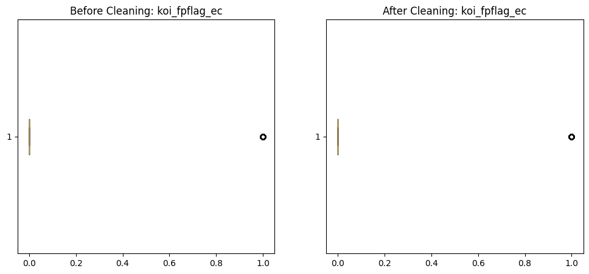

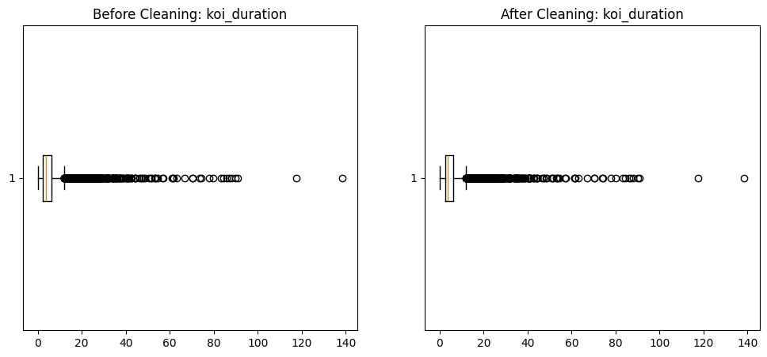

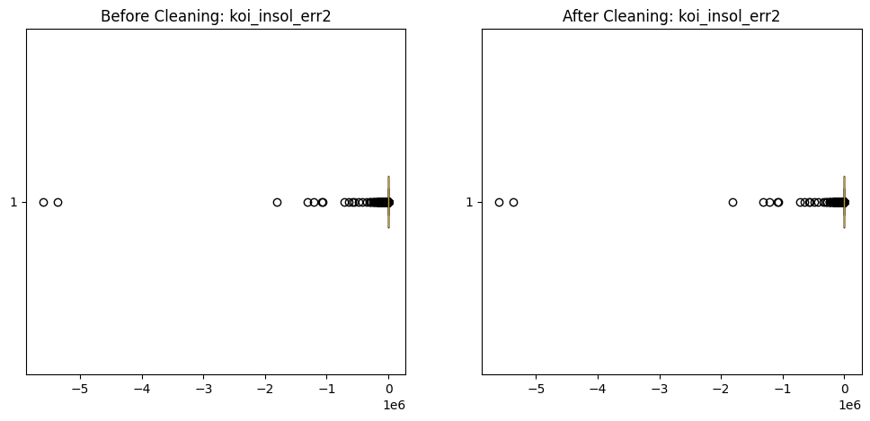

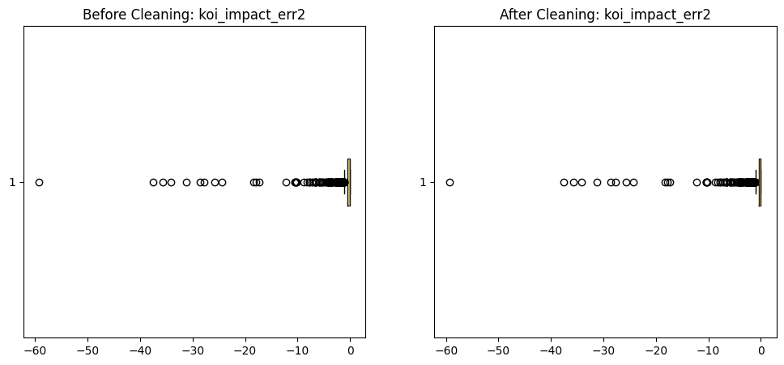

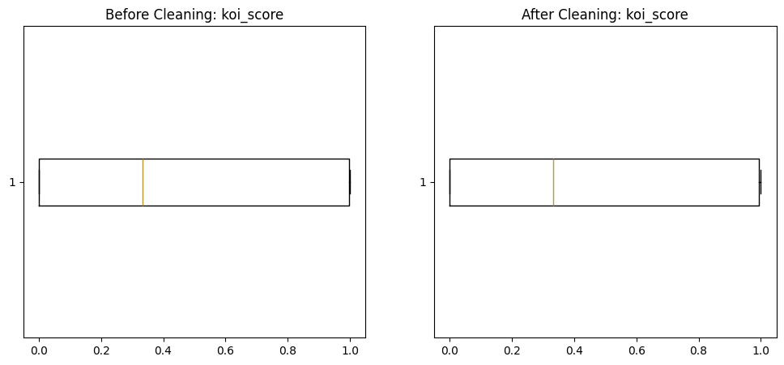

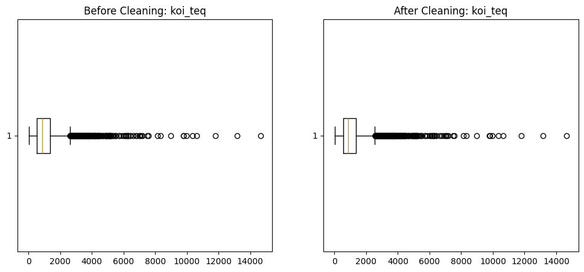

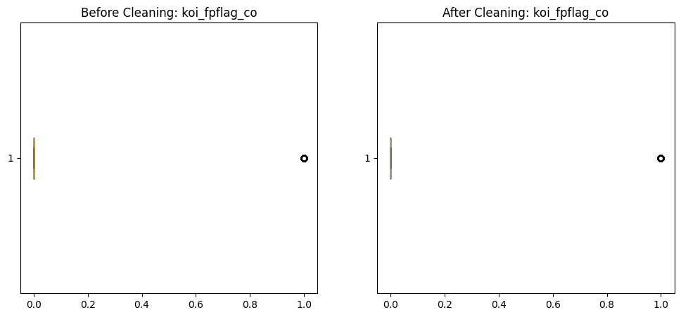

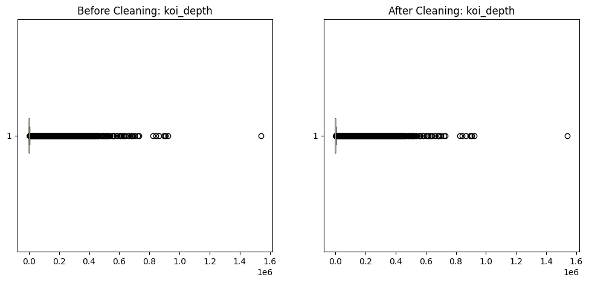

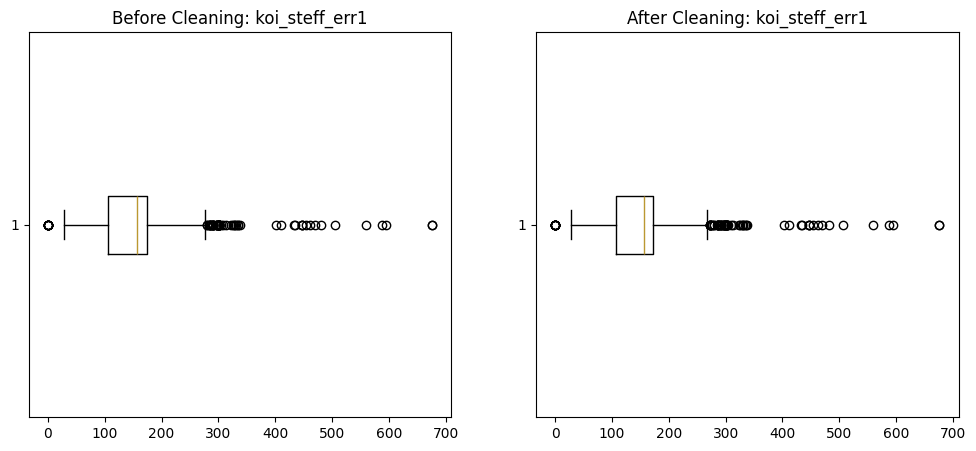

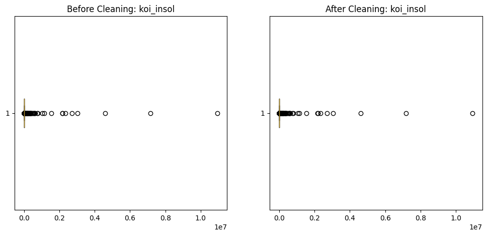

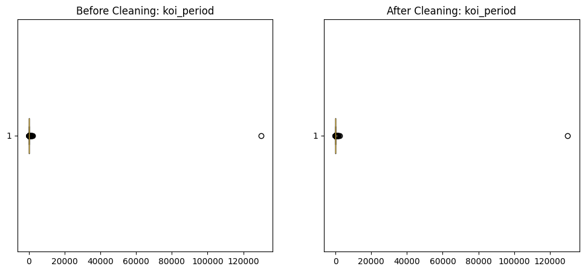

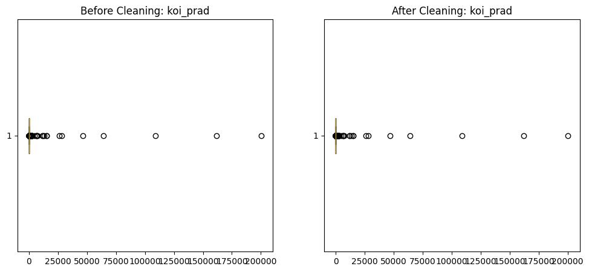

[31 more figures not shown]

```
The following numerical columns were removed during cleaning:
- koi_teq_err1
- koi_teq_err2
```

```python
import matplotlib.pyplot as plt

# Identify numerical columns in original and cleaned datasets
original_numerical_columns = df_original.select_dtypes(include=['number']).columns
cleaned_numerical_columns = df_cleaned.select_dtypes(include=['number']).columns

# Find common numerical columns
common_numerical_columns = list(set(original_numerical_columns) & set(cleaned_numerical_columns))

# Identify dropped numerical columns
dropped_columns = list(set(original_numerical_columns) - set(cleaned_numerical_columns))
print(f"Dropped Columns: {dropped_columns}")

# Compare numerical columns that exist in both datasets
for column in common_numerical_columns:
    plt.figure(figsize=(12, 5))

    # Before cleaning
    plt.subplot(1, 2, 1)
    plt.boxplot(df_original[column].dropna(), vert=False)
    plt.title(f'Before Cleaning: {column}')

    # After cleaning
    plt.subplot(1, 2, 2)
    plt.boxplot(df_cleaned[column].dropna(), vert=False)
    plt.title(f'After Cleaning: {column}')

    plt.show()

# Optionally print dropped columns for reporting purposes
if dropped_columns:
    print("The following numerical columns were removed during cleaning:")
    for col in dropped_columns:
        print(f"- {col}")
```

### **Missing Values**

Original dataset contained missing values across several columns. Cleaned dataset has **no missing values**.

### **Statistical Differences**

Summary statistics for numerical columns indicate refined and consistent data.

### **Dropped Columns**

Columns dropped were those with high missing data or irrelevant to the analysis.

### **Conclusion**

Understood the data types and distributions aids in selecting appropriate preprocessing and modeling techniques. The cleaned dataset is ready for further analysis and modeling, with enhanced consistency and no missing or irrelevant data. This ensures robust and accurate outcomes for downstream tasks.

# Kepler Exoplanet Classification: Exploratory Data Analysis

This notebook performs a detailed exploratory data analysis on the Kepler exoplanet dataset for classification purposes. We'll analyze various features to understand their relationships and importance in determining whether a candidate is a confirmed exoplanet or a false positive.

## Dataset Overview

The dataset contains various measurements and characteristics of Kepler Objects of Interest (KOI), including:

- Orbital characteristics (period, duration, etc.)
- Physical properties (radius, temperature, etc.)
- Star characteristics (temperature, radius, etc.)
- Classification labels (CONFIRMED, FALSE POSITIVE)

```python
# Import required libraries
import pandas as pd
import numpy as np
import matplotlib.pyplot as plt
import seaborn as sns
from scipy import stats
from sklearn.preprocessing import StandardScaler
from sklearn.feature_selection import mutual_info_classif
from scipy.stats import chi2_contingency
import warnings
from scipy import stats
from sklearn.preprocessing import StandardScaler
from sklearn.decomposition import PCA
from sklearn.manifold import TSNE
from sklearn.cluster import KMeans
from sklearn.ensemble import RandomForestClassifier
from sklearn.preprocessing import LabelEncoder
warnings.filterwarnings('ignore')

# Set plotting style
# plt.style.use('seaborn')
sns.set_palette('husl')
```

## Data Loading and Initial Preparation

First, we'll load the data and prepare it for analysis by:

1. Creating a binary classification target
2. Identifying numerical and categorical features
3. Checking for missing values

```python
# Load and prepare data
def load_and_prepare_data(data):
    # Convert disposition to binary classification
    data['is_confirmed'] = (data['koi_disposition'] == 'CONFIRMED').astype(int)

    # Select relevant numerical features
    numerical_features = [
        'koi_period', 'koi_impact', 'koi_duration',
        'koi_depth', 'koi_prad', 'koi_teq',
        'koi_insol', 'koi_model_snr', 'koi_steff',
        'koi_slogg', 'koi_srad'
    ]

    # Select categorical features
    categorical_features = [
        'koi_fpflag_nt', 'koi_fpflag_ss',
        'koi_fpflag_co', 'koi_fpflag_ec'
    ]

    return data, numerical_features, categorical_features

# Load data
data = df_cleaned
data, numerical_features, categorical_features = load_and_prepare_data(data)

# Display basic information about the dataset
print("Dataset Shape:", data.shape)
print("\nFeature Information:")
data.info()
```

```
Dataset Shape: (9564, 48)

Feature Information:
<class 'pandas.core.frame.DataFrame'>
RangeIndex: 9564 entries, 0 to 9563
Data columns (total 48 columns):
 #   Column             Non-Null Count  Dtype
---  ------             --------------  -----
 0   rowid              9564 non-null   int64
 1   kepid              9564 non-null   int64
 2   kepoi_name         9564 non-null   object
 3   koi_disposition    9564 non-null   object
 4   koi_pdisposition   9564 non-null   object
 5   koi_score          9564 non-null   float64
 6   koi_fpflag_nt      9564 non-null   int64
```

[output cut: 43 more lines]

## Class Distribution Analysis

Understanding the class distribution helps us:

- Identify potential class imbalance issues
- Plan appropriate sampling or weighting strategies
- Set baseline metrics for model evaluation

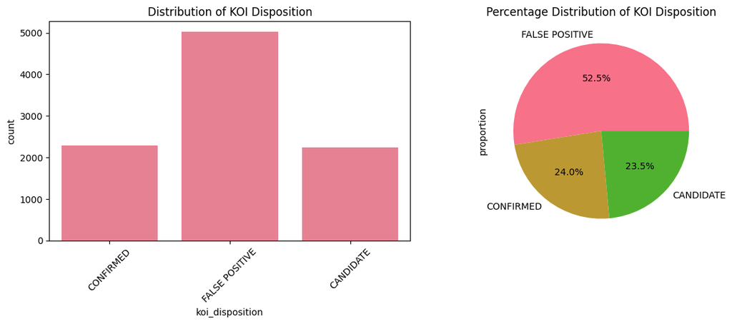

```python
def analyze_class_distribution(data):
    plt.figure(figsize=(12, 5))

    # Plot 1: Count distribution
    plt.subplot(1, 2, 1)
    sns.countplot(data=data, x='koi_disposition')
    plt.title('Distribution of KOI Disposition')
    plt.xticks(rotation=45)

    # Plot 2: Percentage distribution
    plt.subplot(1, 2, 2)
    data['koi_disposition'].value_counts(normalize=True).plot(kind='pie', autopct='%1.1f%%')
    plt.title('Percentage Distribution of KOI Disposition')

    plt.tight_layout()
    plt.show()

analyze_class_distribution(data)
```

The class distribution analysis of Kepler Objects of Interest (KOI) dispositions reveals a notable imbalance among the categories. A count plot shows that "False Positive" cases dominate the dataset, significantly outnumbering "Confirmed" exoplanets and other categories. This indicates that most KOI candidates fail to meet the stringent criteria required for confirmation as exoplanets. The pie chart further highlights this imbalance, with "False Positive" cases comprising the largest proportion, underscoring the challenges in distinguishing true exoplanets from false signals. This class imbalance has significant implications for data modeling and analysis. Machine learning models trained on this dataset may become biased toward predicting the majority class unless appropriate measures are taken. Techniques such as oversampling the minority class, undersampling the majority class, or using weighted loss functions can help mitigate this issue. Moreover, evaluating model performance using metrics like precision, recall, and F1-score becomes crucial to ensure that predictions for minority classes are not overlooked.

**How do preliminary (koi_pdisposition) and final (koi_disposition) classifications relate?**

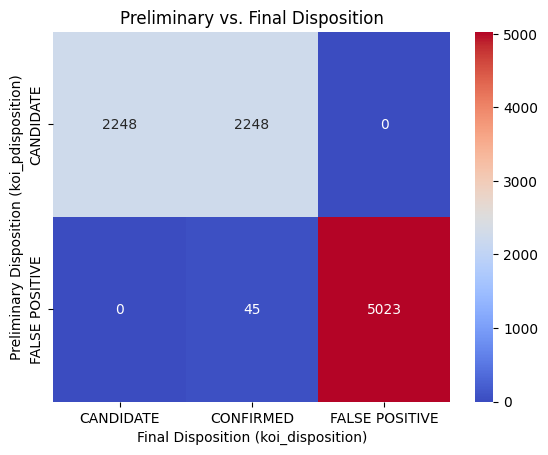

```python
cross_tab = pd.crosstab(data['koi_pdisposition'], data['koi_disposition'])

sns.heatmap(cross_tab, annot=True, fmt='d', cmap='coolwarm')
plt.title('Preliminary vs. Final Disposition')
plt.xlabel('Final Disposition (koi_disposition)')
plt.ylabel('Preliminary Disposition (koi_pdisposition)')
plt.show()
```

## Feature Analysis

### Numerical Features

For each numerical feature, we'll examine:

1. Distribution shape and characteristics
2. Relationship with target variable
3. Presence of outliers
4. Statistical properties

**What is the distribution of koi_score across dispositions?**

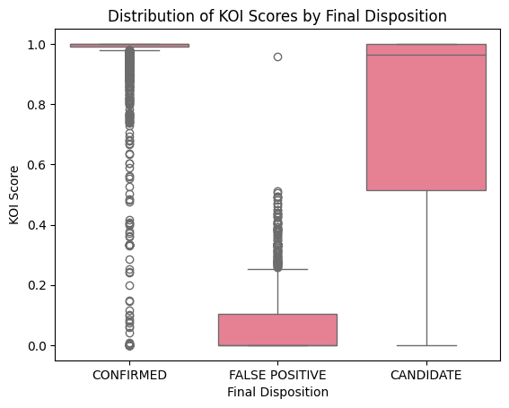

```python
sns.boxplot(data=data, x='koi_disposition', y='koi_score')
plt.title('Distribution of KOI Scores by Final Disposition')
plt.xlabel('Final Disposition')
plt.ylabel('KOI Score')
plt.show()
```

The box plot visualizes the distribution of KOI scores (ranging from 0 to 1) across three categories: Confirmed, False Positive, and Candidate planets. Each category is represented by a box showing the quartile distribution, with whiskers extending to show the full range, and individual points marking outliers. The Confirmed category shows a dense cluster of scores near 1.0, while False Positives display a broader distribution below 0.5.

**Inferences - **

The distribution patterns strongly suggest that KOI scores are reliable indicators of planet confirmation likelihood. Higher scores (close to 1.0) strongly correlate with confirmed planets, indicating the scoring system's effectiveness. The presence of outliers in both Confirmed and False Positive categories suggests that while the score is a good predictor, it shouldn't be the sole criterion for classification. The wide range in the Candidate category indicates uncertainty in classification

### Feature Correlations

Understanding feature correlations helps us:

- Identify potential multicollinearity
- Discover feature relationships
- Guide feature selection

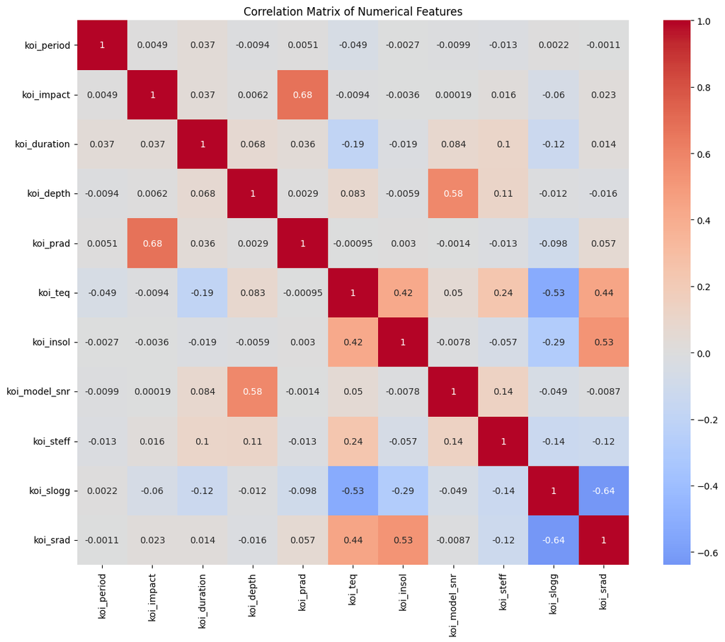

```python
# Create correlation matrix
plt.figure(figsize=(12, 10))
correlation_matrix = data[numerical_features].corr()
sns.heatmap(correlation_matrix, annot=True, cmap='coolwarm', center=0)
plt.title('Correlation Matrix of Numerical Features')
plt.tight_layout()
plt.show()
```

#### Insights from the correlation matrix

Strong Correlations (|r| > 0.5):

1. koi_impact and koi_prad (0.68): Strong positive correlation between impact parameter and planetary radius
2. koi_depth and koi_model_snr (0.58): Transit depth strongly correlates with signal-to-noise ratio
3. koi_slogg and koi_srad (-0.64): Strong negative correlation between stellar surface gravity and stellar radius
4. koi_slogg and koi_teq (-0.53): Inverse relationship between surface gravity and equilibrium temperature
5. koi_srad and koi_insol (0.53): Stellar radius positively correlates with insolation flux

Moderate Correlations (0.3 < |r| < 0.5):

1. koi_teq and koi_insol (0.42): Positive correlation between equilibrium temperature and insolation
2. koi_srad and koi_teq (0.44): Larger stars tend to have higher equilibrium temperatures
3. koi_slogg and koi_insol (-0.29): Weak negative correlation between surface gravity and insolation

Key Insights:

1. Feature Independence:
   - Most features show low correlation with each other
   - koi_period is surprisingly independent of other features (all correlations < 0.05)
   - This independence suggests most features provide unique information for classification
2. Physical Relationships:
   - The correlations reflect known physical relationships in stellar and planetary systems
   - Stellar parameters (srad, slogg, steff) show expected interconnections
   - Transit parameters (depth, SNR) show logical relationships
3. Implications for Modeling:
   - Limited multicollinearity suggests most features can be used together in models
   - Might consider combining highly correlated features (e.g., impact-prad, depth-SNR)
   - Could create interaction terms for physically related parameters
4. Feature Selection Considerations:
   - Most features provide independent information and should be retained
   - Could consider dimensionality reduction for highly correlated groups
   - The independence of period suggests it's an important standalone feature
5. Potential Feature Engineering:
   - Could create composite features from strongly correlated pairs
   - Might develop normalized ratios between related parameters
   - Consider polynomial features for parameters with physical relationships

This correlation analysis suggests a good feature set for classification with minimal redundancy and clear physical relationships between parameters.

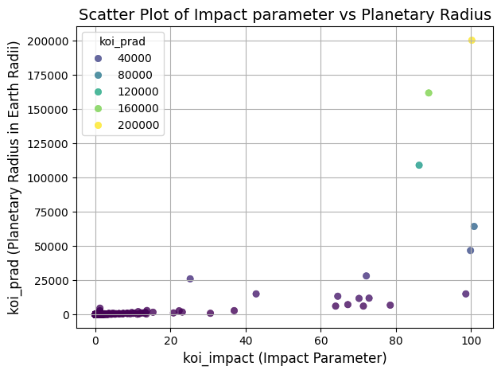

```python
scatter = sns.scatterplot(
    data=data,
    x='koi_impact',
    y='koi_prad',
    palette='viridis',
    hue=data['koi_prad'],
    alpha=0.8,
    edgecolor=None
)

plt.title('Scatter Plot of Impact parameter vs Planetary Radius', fontsize=14)
plt.xlabel('koi_impact (Impact Parameter)', fontsize=12)
plt.ylabel('koi_prad (Planetary Radius in Earth Radii)', fontsize=12)
plt.grid(True)
plt.tight_layout()

plt.show()
```

The scatter plot shows the relationship between the impact parameter (x-axis, ranging from 0 to 100) and planetary radius (y-axis, ranging from 0 to 200,000 Earth radii). Points are color-coded by koi_prad values ranging from 40,000 to 200,000, with a legend showing five different ranges. The majority of points cluster in the lower range of both axes.

There appears to be a positive correlation between impact parameter and planetary radius, particularly at higher values. The clustering of points at lower values suggests that most exoplanet candidates have relatively small radii and low impact parameters. The color gradient reveals that larger planetary radii tend to correspond with higher impact parameters

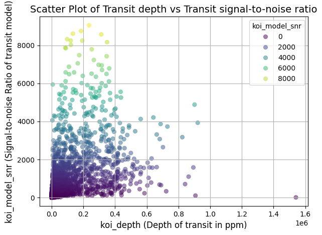

```python
scatter = sns.scatterplot(
    data=data,
    x='koi_depth',
    y='koi_model_snr',
    palette='viridis',
    hue=data['koi_model_snr'],
    alpha=0.5,
    edgecolor=None
)

plt.title('Scatter Plot of Transit depth vs Transit signal-to-noise ratio', fontsize=14)
plt.xlabel('koi_depth (Depth of transit in ppm)', fontsize=12)
plt.ylabel('koi_model_snr (Signal-to-noise Ratio of transit model)', fontsize=12)
plt.grid(True)
plt.tight_layout()

plt.show()
```

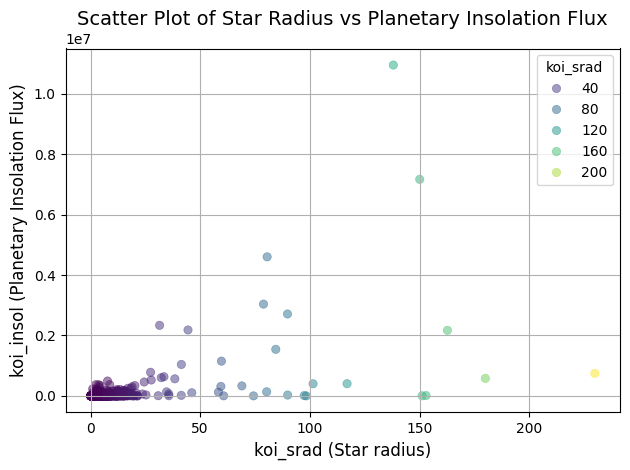

```python
scatter = sns.scatterplot(
    data=data,
    x='koi_srad',
    y='koi_insol',
    palette='viridis',
    hue=data['koi_srad'],
    alpha=0.5,
    edgecolor=None
)

plt.title('Scatter Plot of Star Radius vs Planetary Insolation Flux', fontsize=14)
plt.xlabel('koi_srad (Star radius)', fontsize=12)
plt.ylabel('koi_insol (Planetary Insolation Flux)', fontsize=12)
plt.grid(True)
plt.tight_layout()

plt.show()
```

The relationship between star radius and planetary insolation flux shows an interesting trend where larger stars tend to have planets with higher insolation flux values. Most planets cluster around smaller star radii (below 50 solar radii) with relatively low insolation flux, but there's a notable spread as star size increases.

This pattern suggests that larger stars generally create more intense radiation environments for their planets, though the relationship isn't strictly linear.

**Are high-scoring CANDIDATE planets likely to become CONFIRMED?**

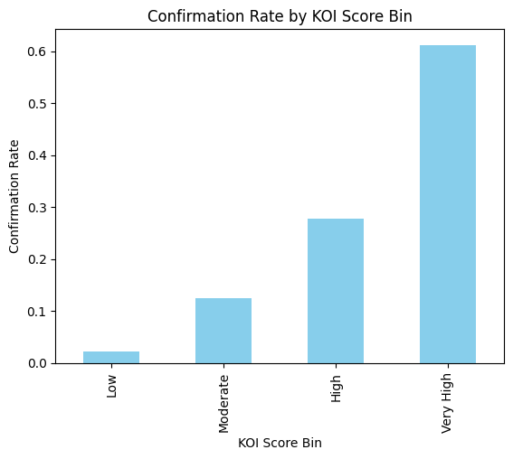

```python
data['score_bins'] = pd.cut(data['koi_score'], bins=[0, 0.5, 0.7, 0.9, 1.0], labels=['Low', 'Moderate', 'High', 'Very High'])

# Count occurrences
confirmation_rates = data[data['koi_disposition'] == 'CONFIRMED'].groupby('score_bins').size() / data.groupby('score_bins').size()

# Plot
confirmation_rates.plot(kind='bar', color='skyblue')
plt.title('Confirmation Rate by KOI Score Bin')
plt.xlabel('KOI Score Bin')
plt.ylabel('Confirmation Rate')
plt.show()
```

The bar chart displays confirmation rates across four KOI score categories: Low, Moderate, High, and Very High. The y-axis shows the confirmation rate from 0 to 0.6 (or 0% to 60%), while the x-axis represents the different score bins. The bars show a clear ascending pattern from left to right, with light blue coloring making the trend easily visible.

**Inferences**-

The strong positive correlation between KOI score and confirmation rate validates the scoring system's effectiveness. The dramatic increase from a 2% confirmation rate in the Low category to 60% in the Very High category demonstrates the score's predictive power. This pattern suggests that the KOI scoring system successfully captures the key indicators of genuine planetary signatures. The stepped increase across categories also provides a practical tool for prioritizing follow-up observations, with higher-scored candidates warranting more immediate attention.

**How many CANDIDATE planets progress to CONFIRMED by score level?**

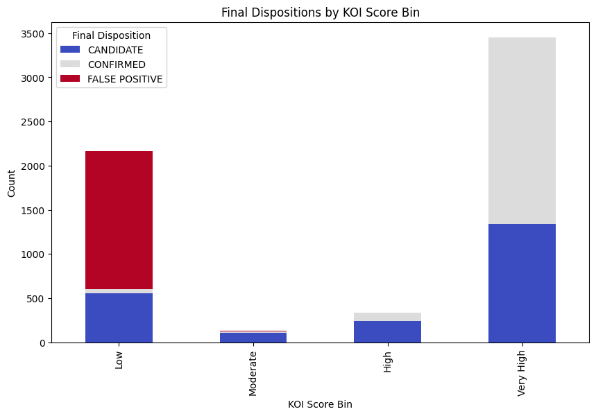

```python
pivot = pd.crosstab(data['score_bins'], data['koi_disposition'])

pivot.plot(kind='bar', stacked=True, figsize=(10, 6), colormap='coolwarm')
plt.title('Final Dispositions by KOI Score Bin')
plt.xlabel('KOI Score Bin')
plt.ylabel('Count')
plt.legend(title='Final Disposition')
plt.show()
```

The stacked bar chart displays the distribution of planetary classifications (Candidate, Confirmed, and False Positive) across four KOI score categories: Low, Moderate, High, and Very High. The y-axis represents the count of objects, reaching up to 3500, while the x-axis shows the KOI score bins. Each bar is segmented into three colors: blue for Candidates, grey for Confirmed planets, and red for False Positives.

In the Low score bin, there's a high proportion of False Positives (red) with some Candidates (blue), suggesting that low KOI scores are strong indicators of non-planetary signals.

The Very High score bin shows a dramatic shift, with a large number of Confirmed planets (grey) and Candidates (blue) but virtually no False Positives, indicating that high KOI scores are reliable predictors of genuine planetary detections.

This pattern validates the KOI scoring system as an effective tool for preliminary planet identification, with higher scores strongly correlating with successful planet confirmation.

**How do features of a specific star system (e.g., orbital period, stellar radius, and stellar effective temperature) compare relative to one another?**

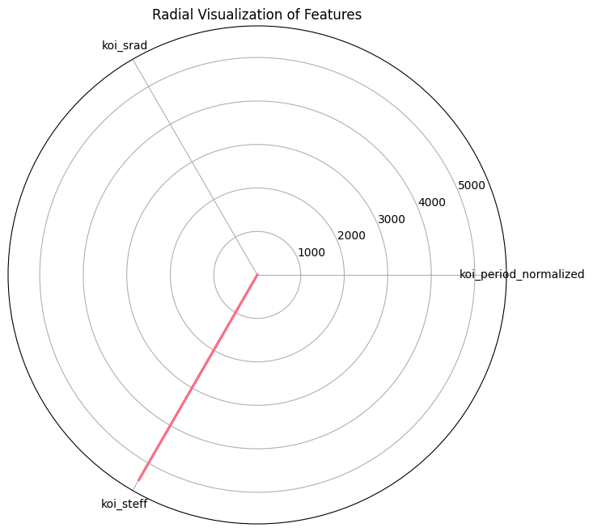

```python
from math import pi

# Sample data for a single star system
radial_data = data[data['kepid'] == data['kepid'].iloc[0]]

# Normalize values for visualization
radial_data['koi_period_normalized'] = radial_data['koi_period'] / radial_data['koi_period'].max()

# Plot
categories = ['koi_period_normalized', 'koi_srad', 'koi_steff']
values = radial_data[categories].mean().tolist()
values += values[:1]  # Close the circle

angles = [n / float(len(categories)) * 2 * pi for n in range(len(categories))]
angles += angles[:1]

plt.figure(figsize=(8, 8))
ax = plt.subplot(111, polar=True)
plt.xticks(angles[:-1], categories)

ax.plot(angles, values, linewidth=2, linestyle='solid')
ax.fill(angles, values, color='blue', alpha=0.3)
plt.title('Radial Visualization of Features')
plt.show()
```

### Feature Importance Analysis

We'll use mutual information to measure the importance of each feature for classification.

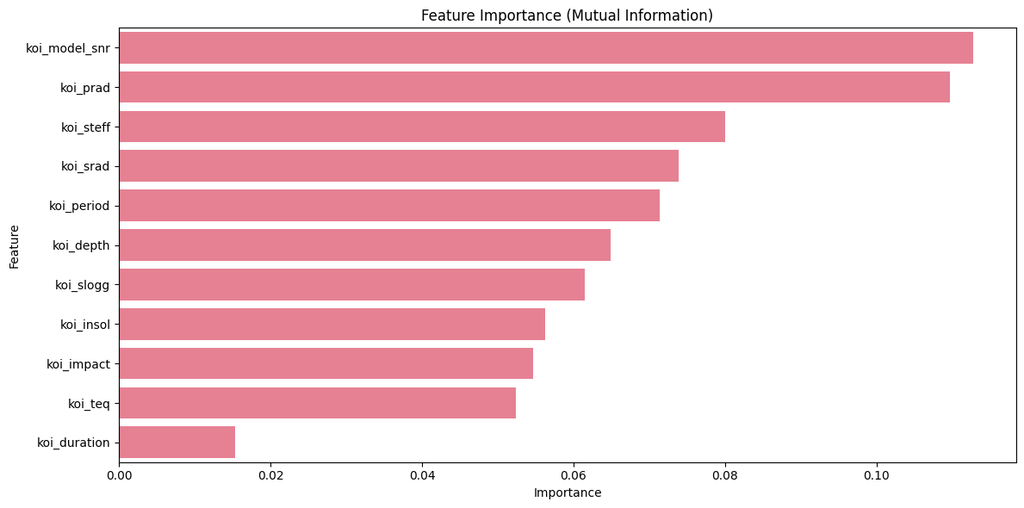

```python
def calculate_feature_importance(data, numerical_features):
    # Prepare data
    X = data[numerical_features]
    y = data['is_confirmed']

    # Scale features
    scaler = StandardScaler()
    X_scaled = scaler.fit_transform(X)
    X_scaled = pd.DataFrame(X_scaled, columns=numerical_features)

    # Calculate mutual information scores
    mi_scores = mutual_info_classif(X_scaled, y)

    # Create and sort feature importance DataFrame
    feature_importance = pd.DataFrame({
        'Feature': numerical_features,
        'Importance': mi_scores
    }).sort_values('Importance', ascending=False)

    # Visualize
    plt.figure(figsize=(12, 6))
    sns.barplot(data=feature_importance, x='Importance', y='Feature')
    plt.title('Feature Importance (Mutual Information)')
    plt.tight_layout()
    plt.show()

    return feature_importance

feature_importance = calculate_feature_importance(data, numerical_features)
```

#### Insights from Feature Importance Analysis

Least Important Feature:

- koi_duration (0.02): Transit duration shows significantly lower importance
  - Might be less reliable for classification
  - Could be more useful when combined with other features

Key Insights:

This analysis suggests focusing on signal quality and basic physical parameters for classification, while using stellar parameters for validation context..